**Nome**: *Federico*  
**Cognome**: *Signoretta*  
**Numero matricola**: 847343  
**E-mail**: f.signoretta@campus.unimib.it  
**A.A.** 2019-2020

# Data Science Lab in Medicine

- Modulo: **Medical Imaging & Big Data**
- Docente: *Isabella Castiglioni*

**Descrizione del problema**: l'obiettivo di questo progetto è quello di discriminare lesioni oncologiche eterogenee da lesioni omogenee, attraverso modelli di machine learning. In particolare, il dataset è composto da 44 immagini già segmentate: esse sono state precedentemente partizionate in regioni significative di interesse (ROI). Da tali immagini verranno estratte delle caratteristiche anatomiche delle lesioni, attraverso le quali sarà succesivamente possibile allenare i modelli predittivi. Per classificare tali lesioni, verranno utilizzati alcuni modelli di machine learning supervisionati e non-supervisionati.

# 1. Import dei pacchetti

```python
import pandas as pd
import numpy as np
import matplotlib.pyplot as plt
import os
import imageio
import warnings
import math

import sklearn
from sklearn.decomposition import FastICA
from skimage import filters

from scipy import stats

from nilearn import plotting

from medpy.io import load

import nibabel as nib
from nibabel.testing import data_path

from sklearn.metrics import confusion_matrix, classification_report
from sklearn.preprocessing import MinMaxScaler
from sklearn.svm import SVC
from sklearn.model_selection import cross_validate, cross_val_score, cross_validate
from sklearn.model_selection import ShuffleSplit
from sklearn.model_selection import GridSearchCV
from sklearn.metrics import f1_score
from sklearn.metrics import make_scorer, accuracy_score, precision_score, recall_score, f1_score
from sklearn.linear_model import LogisticRegression
from sklearn.ensemble import RandomForestClassifier
from sklearn.neighbors import KNeighborsClassifier
from sklearn.ensemble import ExtraTreesClassifier
from sklearn.cluster import KMeans
from sklearn.utils import shuffle

from keras.utils import to_categorical
from keras.models import Sequential
from keras.layers import Dense

from sklearn.model_selection import StratifiedKFold
from sklearn.feature_selection import SelectFromModel


from scipy.stats import entropy
import seaborn as sns
```

# 2. Visualizzazione delle lesioni

In questa sezione, attraverso la libreria *nilearn*, vengono rappresentate le immagini delle lesioni celebrali, in formato *nifti*. Le immagini in questione si riferiscono a lesioni già segentate in precedenza (*ROI*). Attraverso la funzione **plt_glass_brain()** sono tracciate le proiezioni 2D dell'immagine (di default 3 proiezioni: frontale, assiale e laterale).

```python
path = "/Users/feder/Documents/Università/Data Science Lab in Medicine/Medical Imaging & Big Data/Project/code__esempi/lesions/"
path_homog= path + "homogeneous/nifti/"
path_heterog = path + "heterogeneous/nifti/"
```

```python
def plot_lesions(path_type):
    files = os.listdir(path_type)
    for i in range(3):
        plotting.plot_glass_brain(path_type+files[i])
```

## 2.1 Visualizzazione delle lesioni omogenee

Vengono riportati 3 esempi di lesioni omogenee.

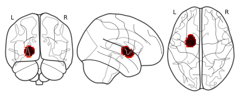

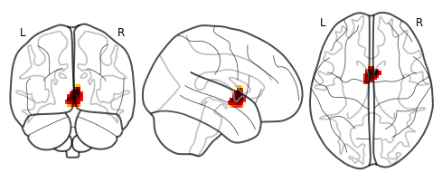

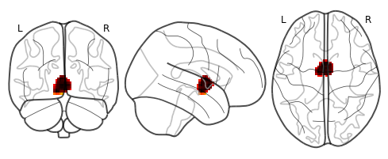

```python
plot_lesions(path_homog)
```

## 2.2 Visualizzazione delle lesioni eterogenee

Vengono riportati 3 esempi di lesioni eterogenee.

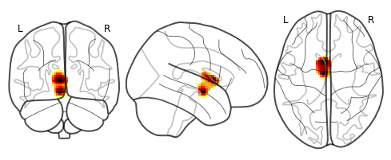

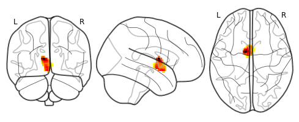

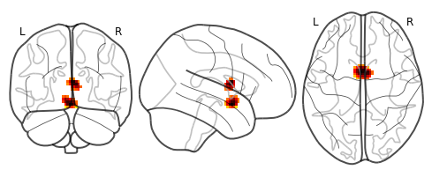

```python
plot_lesions(path_heterog)
```

# 3. Features extraction

In medicina, una tecnica molto utilizzata e semplice per estrarre features dalle immagini è quella che si basa sul dominio di conoscenza del medico. Quindi, spesso, si tratta di estrarre delle caratteristiche anatomiche dalle immagini, basandosi su biomarcatori noti a priori. Le features morfologiche più utilizzate in questo approccio sono: il Metabolic Target Volume (MTV), la supericie, la Spherical Disporportion, la sfericità ed il rapporto superficie-volume.

Quindi, dalle immagini precedentemente visualizzate, sono state estratte le seguenti features:

- **VOLUME**
- **SURFACE**
- **SPHERICAL DISPROPORTION**
- **SPHERICITY**
- **SURFACE-to-VOLUME RATIO**

La funzione **compute_surface()** prende in input l'immagine della lesione (già trasformata in array) e la dimensione dei pixels e ne calcola la superficie. La funzione **create_data()**, dato il percorso delle immagini, crea un vettore *features* contenente le features precedentemente descritte ed un vettore di 0 o 1 (*omogenea*-**0** oppure *eterogenea*-**1**).

```python
def compute_surface(M, pix_dim):
    x__size = M.shape[0]
    y__size = M.shape[1]
    z__size = M.shape[2]
    dx = pix_dim[0]
    dy = pix_dim[1]
    dz = pix_dim[2]

    surface = 0;
    N = np.zeros((x__size,y__size,z__size))

    for k in range(z__size):
        for j in range(y__size):

            if M[1,j,k]>0:
                surface = surface+(dz*dy)
                N[1,j,k] = 1

            if M[x__size-1,j,k]>0:
                surface = surface+(dz*dy)
                N[x__size-1,j,k] = 1


    for k in range(z__size):
        for i in range(x__size):

            if M[i,1,k]>0:
                surface = surface+(dz*dx)
                N[i,1,k] = 1

            if M[i,y__size-1,k]>0:
                surface = surface+(dz*dx)
                N[i,y__size-1,k] = 1


    for j in range(y__size):
        for i in range(x__size):
            if M[i,j,1] > 0:
                surface = surface+(dy*dx)
                N[i,j,1] = 1

            if M[i,j,z__size-1] > 0:
                surface = surface+(dy*dx)
                N[i,j,z__size-1] = 1


    for i in range(x__size):
        for j in range(y__size):
            for k in range(z__size):

                if k > 1 and M[i,j,k] > 0 and M[i,j,k-1] == 0:
                    surface = surface+(dx*dy)
                    N[i,j,k] = 1
                if k < z__size-1 and M[i,j,k] > 0 and M[i,j,k+1] == 0:
                    surface = surface+(dx*dy)
                    N[i,j,k] = 1


                if i > 1 and M[i,j,k] > 0 and M[i-1,j,k] == 0:
                    surface = surface+(dz*dy)
                    N[i,j,k] = 1
                if i < x__size-1 and M[i,j,k] > 0 and M[i+1,j,k] == 0:
                    surface = surface+(dz*dy)
                    N[i,j,k] = 1


                if j > 1 and M[i,j,k] > 0 and M[i,j-1,k] == 0:
                    surface = surface+(dz*dx)
                    N[i,j,k] = 1
                if j < y__size-1 and M[i,j,k] > 0 and M[i,j+1,k] == 0:
                    surface = surface+(dz*dx)
                    N[i,j,k] = 1

    return surface, N
```

```python
def create_data(path_type, y):

    data = []
    features = []
    files = os.listdir(path_type)

    for i in range(len(files)):
        img = nib.load(path_type+files[i])

        # Volume Lesione
        img_values = img.get_fdata()


        pix_dim = img.header['pixdim'][1:4]/10
        dim = img.header['dim'][1:4]


        #VOLUME
        lesion_voxels = np.where(img_values>0,1,0).sum()
        voxel_volume = (pix_dim).prod()
        lesion_volume = lesion_voxels*voxel_volume

        #SURFACE
        surf = compute_surface(img_values, pix_dim)

        lesion_area = surf[0]

        #SPHERICAL DISPROPORTION
        R_equiv = (lesion_volume*3/(4*math.pi))**(1/3);
        spherical_disproportion = lesion_area/(4*math.pi*R_equiv**2)

        #SPHERICITY
        sphericity = (math.pi**(1/3)*6*lesion_volume**(2/3))/lesion_area

        #SURFACE-to-VOLUME RATIO
        surfacevolume_ratio = lesion_area/lesion_volume

        data.append(img_values)
        features.append([lesion_volume, lesion_area, spherical_disproportion,
                   sphericity, surfacevolume_ratio])

    #data = np.vstack(data)
    label = [y]*len(data)


    return features, label, data
```

## 3.1 Creazione features e label

In questa sezione, vengono create le features associate alle immagini e le relative labels (*omogenea*-**0** oppure *eterogenea*-**1**) e vengono unite, creando la variabile **X** (contenente le features estratte) e la variabile **y** (contenente le labels).

```python
X_homog, y_homog, images_homog = create_data(path_homog,0)
X_heterog , y_heterog, images_heterog = create_data(path_heterog,1)

X = np.concatenate((X_homog,X_heterog), axis=0)
y = np.concatenate((y_homog,y_heterog), axis=0)
```

```python
print("Classe 0 - lesione omogenea: ", round(len(y_homog)/(len(y_heterog)+len(y_homog))*100), "%")
```

```
Classe 0 - lesione omogenea:  59 %
```

```python
print("Classe 1 - lesione eterogenea: ", round(len(y_heterog)/(len(y_heterog)+len(y_homog))*100), "%")
```

```
Classe 1 - lesione eterogenea:  41 %
```

Dalle percentuali sopra riportate è possibile osservare un leggero sbilanciamento delle classi: la **classe-0** costutuisce circa il **60%** del dataset, mentre la **classe-1** il **40%**. Di seguito vengono calcolati i pesi da attribuire alle classi, per correggere lo sbilancimaneto.

```python
weights = np.unique(sklearn.utils.class_weight.compute_sample_weight(class_weight='balanced', y=y))

class_weights = {0: weights[0], 1: weights[1]}
class_weights
```

```
{0: 0.8461538461538461, 1: 1.2222222222222223}
```

## 3.2 Normalizzazione dei dati e shuffle

I dati vengono normalizzati tra 0 e 1 (condizione necessaria per ottenere buone performances attraverso i modelli di machine learning) e viene eseguito uno *shuffle*, fissando il seme a *42*.

```python
scaler = MinMaxScaler((0,1))
scaler.fit(X)
X = scaler.transform(X)

X, y = shuffle(X,y, random_state=42)
```

## 3.3 Features importance

Attraverso il modello **Extra Trees Classifier** (con numero di stimatori pari a 250), è stata stimata l'importanza delle features rispetto alla variabile target.

```
Feature ranking:
1. lesion_volume (0.23292199856691306)
2. lesion_area (0.22943087325709904)
3. spherical_disproportion (0.19995011399285573)
4. sphericity (0.19541412537277994)
5. surfacevolume_ratio (0.1422828888103522)
```

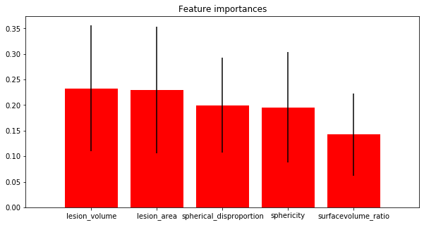

```python
# Build a forest and compute the impurity-based feature importances
forest = ExtraTreesClassifier(n_estimators=250,
                              random_state=1)

forest.fit(X, y)

importances = forest.feature_importances_
std = np.std([tree.feature_importances_ for tree in forest.estimators_],
             axis=0)
indices = np.argsort(importances)[::-1]

# Print the feature ranking
print("Feature ranking:")

features_name = ['lesion_volume', 'lesion_area', 'spherical_disproportion',
                   'sphericity', 'surfacevolume_ratio']

for f in range(X.shape[1]):
    print(str(f+1)+".", features_name[f], "("+str(importances[indices[f]])+")")

# Plot the impurity-based feature importances of the forest
plt.figure(figsize=(10,5))
plt.title("Feature importances")
plt.bar(range(X.shape[1]), importances[indices],
        color="r", yerr=std[indices], align="center")
plt.xticks(range(X.shape[1]), features_name)
plt.xlim([-1, X.shape[1]])
plt.show()
```

# 4. Modelli di classificazione

```python
cv = StratifiedKFold(n_splits=6, shuffle=True, random_state=1234)

def classification_report_with_accuracy_score(y_true, y_pred):
    print("\n",classification_report(y_true, y_pred)) # print classification report
    return accuracy_score(y_true, y_pred) # return accuracy score

scoring = {'report': make_scorer(classification_report_with_accuracy_score)}

def plot_performances(results):
    accuracy = results['test_report']
    x = np.arange(len(accuracy))
    plt.figure(figsize=(15,5))
    plt.bar(x, accuracy, color='steelblue', width=0.4, alpha=.8)
    plt.axhspan(ymin=min(accuracy),ymax=max(accuracy),color ="gray", linestyle ="-", alpha=0.3)
    plt.axhline(y=np.mean(accuracy), color ="darkgray", linestyle ="--")
    #plt.xticks(x, ('k=1','k=2', 'k=3', 'k=4', 'k=5', 'k=6'))
    plt.title('Accuracy values on Test set')
    plt.grid(True, alpha=0.3)
    plt.show()


    max_ = round((max(accuracy))*100, 2)
    min_ = round((min(accuracy))*100,2)
    print('Avarage Accuracy: ', round(np.mean(accuracy)*100,2), "% (min:", min_, "% - max:", max_, "%)")


def plot_performances_ann(accuracy_list):
    accuracy = accuracy_list
    x = np.arange(len(accuracy_list))
    plt.figure(figsize=(15,5))
    plt.bar(x, accuracy, color='steelblue', width=0.4, alpha=.8)
    plt.axhspan(ymin=min(accuracy),ymax=max(accuracy),color ="gray", linestyle ="-", alpha=0.3)
    plt.axhline(y=np.mean(accuracy), color ="darkgray", linestyle ="--")
   # plt.xticks(x, ('k=1','k=2', 'k=3', 'k=4', 'k=5', 'k=6'))
    plt.title('Accuracy values on Test set')
    plt.grid(True, alpha=0.3)
    plt.show()


    max_ = round((max(accuracy))*100, 2)
    min_ = round((min(accuracy))*100,2)
    print('Avarage Accuracy: ', round(np.mean(accuracy)*100,2), "% (min:", min_, "% - max:", max_, "%)")
          # "% ", round(min_,2) ,"%  (\ max:", round(max_,2) "%)\ -------------------------------")
```

## 4.1 Support Vector Classifier - SVC

Per la scelta degli iper-parametri del modello SVC è stata utilizzata una *Grid Serach*, attraverso la quale è stato possibile ottenere la miglior combinazione dei valori *C* e *gamma*.

```python
param_grid = {'C':[0.1, 1, 10, 100, 200, 300, 500, 1000, 2500],
              'gamma': [0.0001, 0.001, 0.01, 0.1, 1],
              'kernel': ["linear"]}

svc = GridSearchCV(SVC(class_weight=class_weights, probability=True), param_grid).fit(X,y)
results_svc = cross_validate(svc, X, y, cv=cv, scoring=scoring)
```

```
               precision    recall  f1-score   support

           0       0.71      1.00      0.83         5
           1       1.00      0.33      0.50         3

    accuracy                           0.75         8
   macro avg       0.86      0.67      0.67         8
weighted avg       0.82      0.75      0.71         8


               precision    recall  f1-score   support

           0       0.71      1.00      0.83         5
           1       1.00      0.33      0.50         3

    accuracy                           0.75         8
   macro avg       0.86      0.67      0.67         8
weighted avg       0.82      0.75      0.71         8


               precision    recall  f1-score   support

           0       0.80      1.00      0.89         4
           1       1.00      0.67      0.80         3

    accuracy                           0.86         7
   macro avg       0.90      0.83      0.84         7
weighted avg       0.89      0.86      0.85         7


               precision    recall  f1-score   support

           0       0.75      0.75      0.75         4
           1       0.67      0.67      0.67         3

    accuracy                           0.71         7
   macro avg       0.71      0.71      0.71         7
weighted avg       0.71      0.71      0.71         7


               precision    recall  f1-score   support

           0       0.80      1.00      0.89         4
           1       1.00      0.67      0.80         3

    accuracy                           0.86         7
   macro avg       0.90      0.83      0.84         7
weighted avg       0.89      0.86      0.85         7


               precision    recall  f1-score   support

           0       0.80      1.00      0.89         4
           1       1.00      0.67      0.80         3

    accuracy                           0.86         7
   macro avg       0.90      0.83      0.84         7
weighted avg       0.89      0.86      0.85         7
```

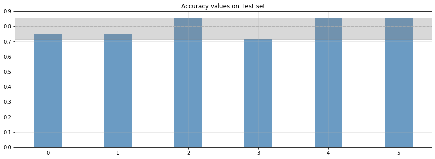

```
Avarage Accuracy:  79.76 % (min: 71.43 % - max: 85.71 %)
```

```python
plot_performances(results_svc)
```

## 4.2 Regressione Logistica

```python
logic_reg = LogisticRegression(class_weight=class_weights, random_state=1)
results_logreg = cross_validate(logic_reg, X, y, cv=cv, scoring=scoring)
```

```
               precision    recall  f1-score   support

           0       0.60      0.60      0.60         5
           1       0.33      0.33      0.33         3

    accuracy                           0.50         8
   macro avg       0.47      0.47      0.47         8
weighted avg       0.50      0.50      0.50         8


               precision    recall  f1-score   support

           0       0.67      0.80      0.73         5
           1       0.50      0.33      0.40         3

    accuracy                           0.62         8
   macro avg       0.58      0.57      0.56         8
weighted avg       0.60      0.62      0.60         8


               precision    recall  f1-score   support

           0       0.80      1.00      0.89         4
           1       1.00      0.67      0.80         3

    accuracy                           0.86         7
   macro avg       0.90      0.83      0.84         7
weighted avg       0.89      0.86      0.85         7


               precision    recall  f1-score   support

           0       0.67      1.00      0.80         4
           1       1.00      0.33      0.50         3

    accuracy                           0.71         7
   macro avg       0.83      0.67      0.65         7
weighted avg       0.81      0.71      0.67         7


               precision    recall  f1-score   support

           0       0.80      1.00      0.89         4
           1       1.00      0.67      0.80         3

    accuracy                           0.86         7
   macro avg       0.90      0.83      0.84         7
weighted avg       0.89      0.86      0.85         7


               precision    recall  f1-score   support

           0       0.67      0.50      0.57         4
           1       0.50      0.67      0.57         3

    accuracy                           0.57         7
   macro avg       0.58      0.58      0.57         7
weighted avg       0.60      0.57      0.57         7
```

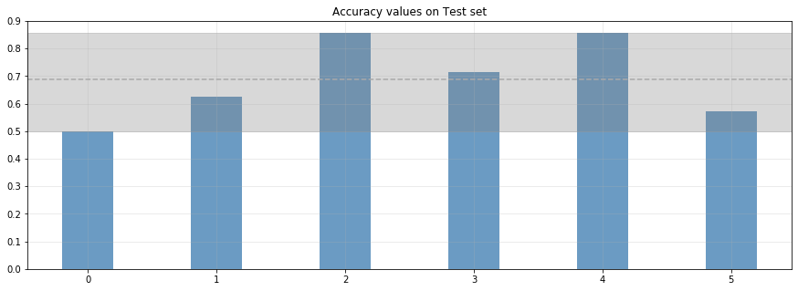

```
Avarage Accuracy:  68.75 % (min: 50.0 % - max: 85.71 %)
```

```python
plot_performances(results_logreg)
```

## 4.3 Random Forest

```python
rf = RandomForestClassifier(max_depth=2, random_state=1, class_weight=class_weights)
results_rf = cross_validate(rf, X, y, cv=cv, scoring=scoring)
```

```
               precision    recall  f1-score   support

           0       0.83      1.00      0.91         5
           1       1.00      0.67      0.80         3

    accuracy                           0.88         8
   macro avg       0.92      0.83      0.85         8
weighted avg       0.90      0.88      0.87         8


               precision    recall  f1-score   support

           0       0.67      0.80      0.73         5
           1       0.50      0.33      0.40         3

    accuracy                           0.62         8
   macro avg       0.58      0.57      0.56         8
weighted avg       0.60      0.62      0.60         8


               precision    recall  f1-score   support

           0       0.75      0.75      0.75         4
           1       0.67      0.67      0.67         3

    accuracy                           0.71         7
   macro avg       0.71      0.71      0.71         7
weighted avg       0.71      0.71      0.71         7


               precision    recall  f1-score   support

           0       0.60      0.75      0.67         4
           1       0.50      0.33      0.40         3

    accuracy                           0.57         7
   macro avg       0.55      0.54      0.53         7
weighted avg       0.56      0.57      0.55         7


               precision    recall  f1-score   support

           0       0.80      1.00      0.89         4
           1       1.00      0.67      0.80         3

    accuracy                           0.86         7
   macro avg       0.90      0.83      0.84         7
weighted avg       0.89      0.86      0.85         7


               precision    recall  f1-score   support

           0       1.00      1.00      1.00         4
           1       1.00      1.00      1.00         3

    accuracy                           1.00         7
   macro avg       1.00      1.00      1.00         7
weighted avg       1.00      1.00      1.00         7
```

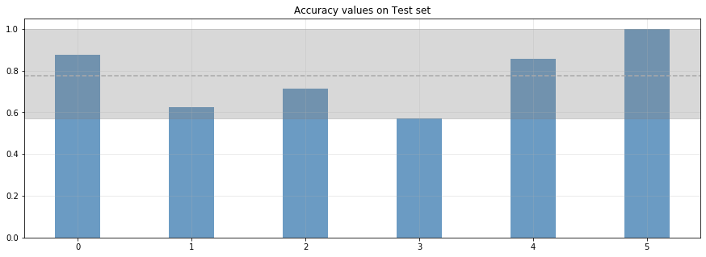

```
Avarage Accuracy:  77.38 % (min: 57.14 % - max: 100.0 %)
```

```python
plot_performances(results_rf)
```

## 4.4 K-Nearest Neighbors

```python
neigh = KNeighborsClassifier(n_neighbors=5)#.fit(X, y)
results_kn = cross_validate(neigh, X, y, cv=cv, scoring=scoring)
```

```
               precision    recall  f1-score   support

           0       0.80      0.80      0.80         5
           1       0.67      0.67      0.67         3

    accuracy                           0.75         8
   macro avg       0.73      0.73      0.73         8
weighted avg       0.75      0.75      0.75         8


               precision    recall  f1-score   support

           0       0.71      1.00      0.83         5
           1       1.00      0.33      0.50         3

    accuracy                           0.75         8
   macro avg       0.86      0.67      0.67         8
weighted avg       0.82      0.75      0.71         8


               precision    recall  f1-score   support

           0       0.75      0.75      0.75         4
           1       0.67      0.67      0.67         3

    accuracy                           0.71         7
   macro avg       0.71      0.71      0.71         7
weighted avg       0.71      0.71      0.71         7


               precision    recall  f1-score   support

           0       0.75      0.75      0.75         4
           1       0.67      0.67      0.67         3

    accuracy                           0.71         7
   macro avg       0.71      0.71      0.71         7
weighted avg       0.71      0.71      0.71         7


               precision    recall  f1-score   support

           0       0.60      0.75      0.67         4
           1       0.50      0.33      0.40         3

    accuracy                           0.57         7
   macro avg       0.55      0.54      0.53         7
weighted avg       0.56      0.57      0.55         7


               precision    recall  f1-score   support

           0       0.80      1.00      0.89         4
           1       1.00      0.67      0.80         3

    accuracy                           0.86         7
   macro avg       0.90      0.83      0.84         7
weighted avg       0.89      0.86      0.85         7
```

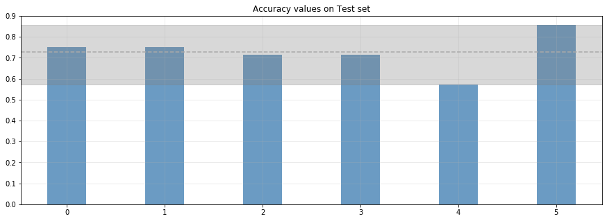

```
Avarage Accuracy:  72.62 % (min: 57.14 % - max: 85.71 %)
```

```python
plot_performances(results_kn)
```

## 4.5 K-Means

```python
kmeans = KMeans(n_clusters=2)
results_km = cross_validate(kmeans, X, y, cv=cv, scoring=scoring)
```

```
               precision    recall  f1-score   support

           0       0.60      0.60      0.60         5
           1       0.33      0.33      0.33         3

    accuracy                           0.50         8
   macro avg       0.47      0.47      0.47         8
weighted avg       0.50      0.50      0.50         8


               precision    recall  f1-score   support

           0       0.67      0.40      0.50         5
           1       0.40      0.67      0.50         3

    accuracy                           0.50         8
   macro avg       0.53      0.53      0.50         8
weighted avg       0.57      0.50      0.50         8


               precision    recall  f1-score   support

           0       0.00      0.00      0.00         4
           1       0.33      0.67      0.44         3

    accuracy                           0.29         7
   macro avg       0.17      0.33      0.22         7
weighted avg       0.14      0.29      0.19         7


               precision    recall  f1-score   support

           0       0.00      0.00      0.00         4
           1       0.33      0.67      0.44         3

    accuracy                           0.29         7
   macro avg       0.17      0.33      0.22         7
weighted avg       0.14      0.29      0.19         7


               precision    recall  f1-score   support

           0       0.25      0.25      0.25         4
           1       0.00      0.00      0.00         3

    accuracy                           0.14         7
   macro avg       0.12      0.12      0.12         7
weighted avg       0.14      0.14      0.14         7


               precision    recall  f1-score   support

           0       0.40      0.50      0.44         4
           1       0.00      0.00      0.00         3

    accuracy                           0.29         7
   macro avg       0.20      0.25      0.22         7
weighted avg       0.23      0.29      0.25         7
```

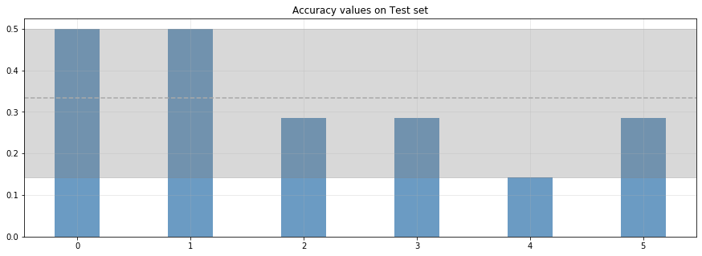

```
Avarage Accuracy:  33.33 % (min: 14.29 % - max: 50.0 %)
```

```python
plot_performances(results_km)
```

## 4.6 Artificial Neural Network

La rete è stata creata con una struttura ad imbuto, composta da 7 strati nascosti (rispettivamente *1024, 512, 256, 128, 64, 32, 16* neuroni) con funzione di attivazione *relu*. Il layer finale di output, ha come funzione di attivazione *softmax*. Come funzione di loss è stata utlizzata una *binary crossentropy* e come funzione di ottimizzazione *adam*. Il trainig del modello è stato eseguito su 200 epoche e con dimensione di batch 32.

```python
acc_list=[]

Y = to_categorical(y,2)

for train, test in cv.split(X, y):

  # create model
    model = Sequential()
    model.add(Dense(1024, input_shape=(5,), activation = "relu"))
    model.add(Dense(512, activation = "relu"))
    model.add(Dense(256, activation = "relu"))
    model.add(Dense(128, activation = "relu"))
    model.add(Dense(64, activation = "relu"))
    model.add(Dense(32, activation = "relu"))
    model.add(Dense(16, activation = "relu"))
    model.add(Dense(2, activation = 'softmax'))

    # Compile model
    model.compile(loss='binary_crossentropy', optimizer='adam', metrics=['accuracy'])

    # Fit the model
    model.fit(X[train], Y[train], epochs=200, batch_size=32, verbose=0, class_weight=class_weights)

    # evaluate the model
    #scores = model.evaluate(X[test], Y[test], verbose=0)
    y_pred = model.predict(X[test])
    y_pred = np.argmax(y_pred, axis = 1)
    y_test = np.argmax(Y[test], axis = 1)
    report = classification_report(y_test, y_pred, output_dict=True)
    acc = pd.DataFrame.from_dict(report)['accuracy'][0]
    acc_list.append(acc)
    print(classification_report(y_test, y_pred, digits = 2))
```

```
WARNING:tensorflow:From C:\Users\feder\anaconda3\lib\site-packages\tensorflow\python\ops\math_grad.py:1250: add_dispatch_support.<locals>.wrapper (from tensorflow.python.ops.array_ops) is deprecated and will be removed in a future version.
Instructions for updating:
Use tf.where in 2.0, which has the same broadcast rule as np.where
WARNING:tensorflow:From C:\Users\feder\anaconda3\lib\site-packages\keras\backend\tensorflow_backend.py:422: The name tf.global_variables is deprecated. Please use tf.compat.v1.global_variables instead.

              precision    recall  f1-score   support

           0       0.67      0.40      0.50         5
           1       0.40      0.67      0.50         3

    accuracy                           0.50         8
   macro avg       0.53      0.53      0.50         8
weighted avg       0.57      0.50      0.50         8

              precision    recall  f1-score   support

           0       0.67      0.80      0.73         5
           1       0.50      0.33      0.40         3

    accuracy                           0.62         8
   macro avg       0.58      0.57      0.56         8
weighted avg       0.60      0.62      0.60         8

              precision    recall  f1-score   support

           0       0.80      1.00      0.89         4
           1       1.00      0.67      0.80         3

    accuracy                           0.86         7
   macro avg       0.90      0.83      0.84         7
weighted avg       0.89      0.86      0.85         7

              precision    recall  f1-score   support

           0       0.67      1.00      0.80         4
           1       1.00      0.33      0.50         3

    accuracy                           0.71         7
   macro avg       0.83      0.67      0.65         7
weighted avg       0.81      0.71      0.67         7

              precision    recall  f1-score   support

           0       0.67      1.00      0.80         4
           1       1.00      0.33      0.50         3

    accuracy                           0.71         7
   macro avg       0.83      0.67      0.65         7
weighted avg       0.81      0.71      0.67         7

              precision    recall  f1-score   support

           0       1.00      0.25      0.40         4
           1       0.50      1.00      0.67         3

    accuracy                           0.57         7
   macro avg       0.75      0.62      0.53         7
weighted avg       0.79      0.57      0.51         7
```

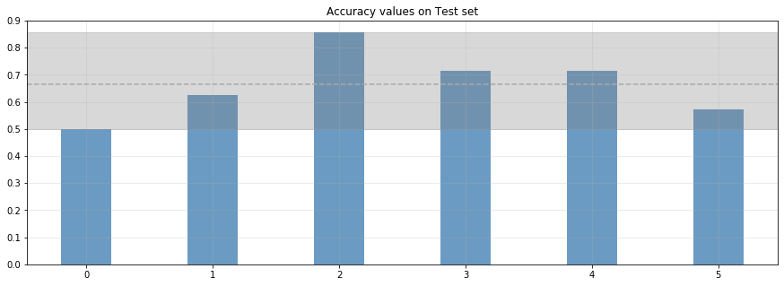

```
Avarage Accuracy:  66.37 % (min: 50.0 % - max: 85.71 %)
```

```python
plot_performances_ann(acc_list)
```

# 5. Risultati

Osservando le prestazioni ottenute dai modelli in k-fold cross validation, è possibile affermare che il modello migliore risulta essere il **Support Vector Classifier** con circa il **80%** di **accuratezza media**. Da notare, però, che tale valore ha un intervallo di variazione di circa il 14% (*min: 71.43% - max: 85.71%*): questo ci suggerisce che il modello è molto sensibile ai dati di test che gli vengono forniti. In conclusione, è possibile affermare che il modello non sarà in grado di pervedere con ottima accuratezza il tipo di lesione: la ragione potrebbe essere legata al ristretto numero di immagini (44) utilizzate per allenare i modelli. Aumentando il numero di immagini si potrebbero ottenere risultati migliori e più convincenti sia sulla SVC che su altri modelli.